# Post Interview Task

Piyumi Pussalamankada

16/02/2021

### Introduction

The Stats NZ covid-19 data portal presents observations across New Zealand to identify the impact of Covid-19 pandamic. These observations records economic, health, income support, and social aspects of COVID-19.There are 9 attributes in this data portal which includes factors, strings, and numbers.This report demonstrate the impact of Covid-19 on the wellbeing of New Zealanders.

Fisrtly, the downloaded dataset was observed to get an overall idea about the data types. Before going to further analysis, some changes had to be carried out to prouce an accurate report.The rows with NA values was removed. Parameter column was initially a factor column. Type of this was changed to date format When the time-series plots were introduced based on the parameter.

wellbeing of people depends on many factors such as money, career,leisure persuits, and health. The attempt of this report was to produce how these wellbeing factors have changed during the Covid-19 pandamic.

### Weekly median earnings impacted during the pandamic

Money is one of main factor that affects the wellbeing of people.

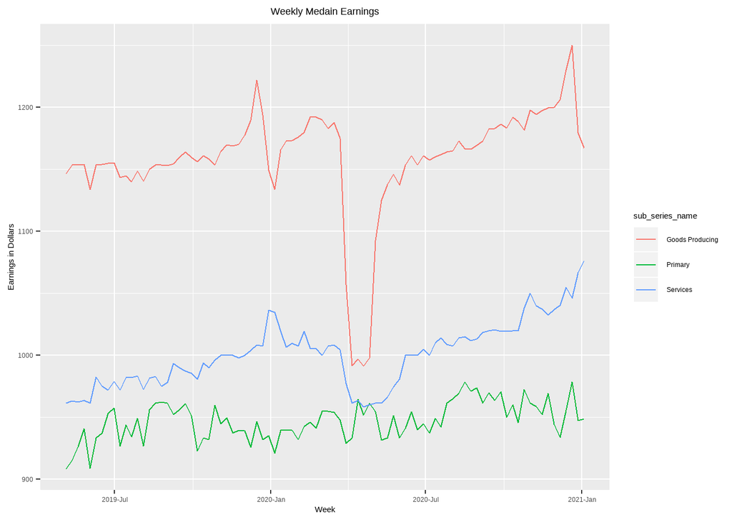

Figure 1: Trend on weekly median earnings

The above graphs show the weekly medain earnings of Goods produced, primary and services over the weeks started from May 2019 to January 2021. Firstly, the graph of total weekly medain earning was showed in the same graph, but it was a suprise to see that it lied between the graph of goods producing and services. Therefore, the total weekly median earning graph was removed because it’s unexceptable to see the graph in between. This may be due to the inproper recording of value or units. Either value should be high or units column should not only include $, instead it should have mentioned as thousands or other higher values.

### The impact on jobseeker support for New Zealenders

Having a stable career is important factor that impact on wellbeing of people.As per the reports we are awrare that many New Zealanders lost their jobs due to this pandamic and many graduates are in a hard situation to find jobs. If those people get any suport to find a job in a situation like this, it will motivate for them to lead a healthier life style.

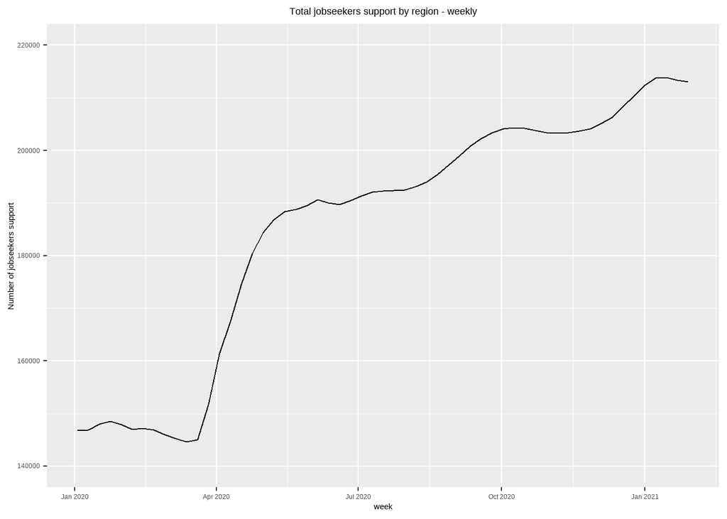

Figure 2: Trend on jobseeker suport

According to the trend of jobseekers support there is a decrease over the period January 2020 to March 2020. It is good to see that during the pandamic there is an accelerated growth for the support of jobseekers. This may reduce the stress of New Zealanders as they feel confortable of the process of finding a job. After June 2020 there can be seen some fluctuations but overall trend is upward.

### The impact on mental health of New Zealanders

Identifying the factors that affect the mental health of people is cruicial to find the ways to cure or minimize it because it affects people by various ways such as low performance of work, and family troubles.

[interactive chart not shown]

Figure 3: Stacked bar chart of mental health of New Zealanders

The above stacked bar chart shows the average percentage of respondents to their mental health during the year 2020. The calmness is the highly affected mental health issue in the society and it seems to be constant throughout the year. The highest percentage of people who were worrying about the family health, nervousness, stress about leaving the family and depression/anxiety can be seen in the month of April.

### The impact on daily border crossings

Traveling is another indicator focussed to identify the pattern of New Zealanders travels before nd after the Covid-19 pandamic.

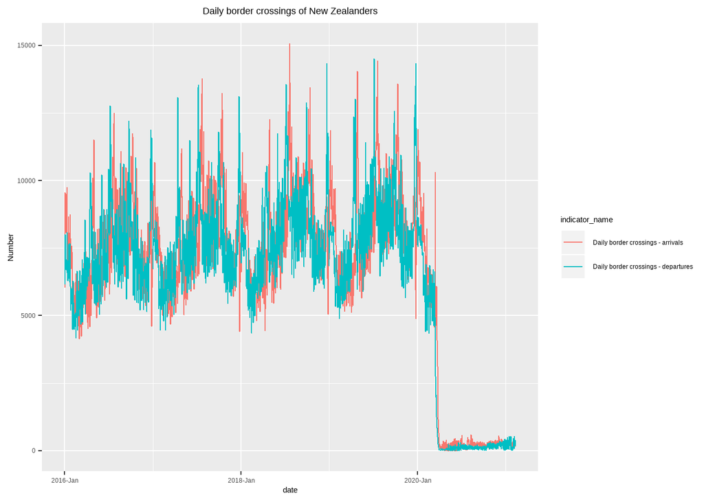

Figure 4: Daily boarder crossings - arrivals & departures

The above graphs show how New Zealanders crosses border daily over the years starting from 2016. According to the graphs, both departures and arrivals have the same pattern of trend and there can be seen a seasonal pattern within each year. A sudden decrease of travels can be observed in the first quarter of 2020 and it continued to be low as never happpened before. The covid-19 has a huge impact over the border crossings of New Zealanders.